# Crime and Communities

**Group Member 1 Name:** Juliann Nguyen **Group Member 1 SID:** 3031972113

The crime and communities dataset contains crime data from communities in the United States. The data combines socio-economic data from the 1990 US Census, law enforcement data from the 1990 US LEMAS survey, and crime data from the 1995 FBI UCR. More details can be found at https://archive.ics.uci.edu/ml/datasets/Communities+and+Crime+Unnormalized.

Once downloaded (from bCourses), the data can be loaded as follows.

```r
library(readr)
CC <- read_csv("crime_and_communities_data.csv")
print(dim(CC))
```

```
[1] 1994  125
```

```r
y <- CC$ViolentCrimesPerPop
X <- subset(CC, select = -c(ViolentCrimesPerPop))
```

# Dataset exploration

In this section, you should provide a thorough exploration of the features of the dataset. Things to keep in mind in this section include:

- Which variables are categorical versus numerical?
- What are the general summary statistics of the data? How can these be visualized?
- Is the data normalized? Should it be normalized?
- Are there missing values in the data? How should these missing values be handled?
- Can the data be well-represented in fewer dimensions?

```r
type_vec <- vector(length = ncol(X))
for (i in 1:ncol(X)) {
  type_vec[i] <- typeof(X[[1]])
}
sum(type_vec == 'double')
```

```
[1] 124
```

```r
ncol(X)
```

```
[1] 124
```

Looking over the data dictionary provided on the website that provides the data and checking the type of each column all of the variables are numeric as they are stored as a double, I would say that the variables are numerical as well. The values such as population, percentage urban, median number of bedrooms, and number of police cars are all numbers that pertain to each community in the dataset. Although none of the variables are categorical, a lot of them are based on categorical things such as per capita income there is an overall measure for the entire population, but there are also other variables that have the per capita income specifically for caucasians, african americans, and other race/ethnicity groups. This pattern follows for some other variables as well such as percent of police given race/ethnicity, percentage of population, and a couple more.

```r
summary_of_vars <- summary(X)
summary_of_vars
```

```
   population      householdsize    racepctblack    racePctWhite    racePctAsian      racePctHisp      agePct12t21
 Min.   :  10005   Min.   :1.600   Min.   : 0.00   Min.   : 2.68   Min.   : 0.0300   Min.   : 0.120   Min.   : 4.58
 1st Qu.:  14359   1st Qu.:2.490   1st Qu.: 0.94   1st Qu.:75.88   1st Qu.: 0.6125   1st Qu.: 0.920   1st Qu.:12.23
 Median :  22681   Median :2.650   Median : 3.15   Median :89.61   Median : 1.2400   Median : 2.340   Median :13.62
 Mean   :  52251   Mean   :2.707   Mean   : 9.51   Mean   :83.49   Mean   : 2.7508   Mean   : 8.482   Mean   :14.43
 3rd Qu.:  43154   3rd Qu.:2.850   3rd Qu.:11.96   3rd Qu.:95.99   3rd Qu.: 2.7375   3rd Qu.: 8.610   3rd Qu.:15.39
 Max.   :7322564   Max.   :5.280   Max.   :96.67   Max.   :99.63   Max.   :57.4600   Max.   :95.290   Max.   :54.40

  agePct12t29     agePct16t24      agePct65up       numbUrban          pctUrban        medIncome         pctWWage
 Min.   : 9.38   Min.   : 4.64   Min.   : 1.660   Min.   :      0   Min.   :  0.00   Min.   : 11576   Min.   :31.68
 1st Qu.:24.38   1st Qu.:11.34   1st Qu.: 8.922   1st Qu.:      0   1st Qu.:  0.00   1st Qu.: 23597   1st Qu.:73.22
 Median :26.77   Median :12.54   Median :11.855   Median :  17348   Median :100.00   Median : 30896   Median :78.38
 Mean   :27.62   Mean   :13.99   Mean   :12.005   Mean   :  46672   Mean   : 69.62   Mean   : 33699   Mean   :78.08
 3rd Qu.:29.18   3rd Qu.:14.36   3rd Qu.:14.547   3rd Qu.:  41932   3rd Qu.:100.00   3rd Qu.: 41215   3rd Qu.:83.70
 Max.   :70.51   Max.   :63.62   Max.   :52.770   Max.   :7322564   Max.   :100.00   Max.   :123625   Max.   :96.62

  pctWFarmSelf      pctWInvInc      pctWSocSec     pctWPubAsst       pctWRetire      medFamInc        perCapInc
 Min.   :0.0000   Min.   : 7.91   Min.   : 4.81   Min.   : 0.500   Min.   : 3.46   Min.   : 13785   Min.   : 5237
 1st Qu.:0.4700   1st Qu.:34.19   1st Qu.:20.98   1st Qu.: 3.362   1st Qu.:12.99   1st Qu.: 29307   1st Qu.:11548
 Median :0.7000   Median :42.38   Median :26.79   Median : 5.720   Median :15.66   Median : 36010   Median :13977
 Mean   :0.8933   Mean   :43.36   Mean   :26.66   Mean   : 6.806   Mean   :16.06   Mean   : 39553   Mean   :15522
 3rd Qu.:1.1100   3rd Qu.:52.07   3rd Qu.:31.84   3rd Qu.: 9.150   3rd Qu.:18.78   3rd Qu.: 46683   3rd Qu.:17774
 Max.   :6.5300   Max.   :89.04   Max.   :76.39   Max.   :26.920   Max.   :45.51   Max.   :131315   Max.   :63302

  whitePerCap     blackPerCap      indianPerCap     AsianPerCap      OtherPerCap       HispPerCap     NumUnderPov
 Min.   : 5472   Min.   :     0   Min.   :     0   Min.   :     0   Min.   :     0   Min.   :    0   Min.   :     78.0
 1st Qu.:12596   1st Qu.:  6706   1st Qu.:  6336   1st Qu.:  8441   1st Qu.:  5500   1st Qu.: 7253   1st Qu.:    936.2
 Median :15028   Median :  9664   Median :  9834   Median : 12331   Median :  8144   Median : 9676   Median :   2217.5
 Mean   :16535   Mean   : 11472   Mean   : 12257   Mean   : 14284   Mean   :  9375   Mean   :10989   Mean   :   7398.4
 3rd Qu.:18610   3rd Qu.: 14464   3rd Qu.: 14690   3rd Qu.: 17346   3rd Qu.: 11378   3rd Qu.:13360   3rd Qu.:   5097.5
 Max.   :68850   Max.   :212120   Max.   :480000   Max.   :106165   Max.   :137000   Max.   :54648   Max.   :1384994.0
                                                                    NA's   :1
 PctPopUnderPov   PctLess9thGrade   PctNotHSGrad    PctBSorMore    PctUnemployed      PctEmploy      PctEmplManu
 Min.   : 0.640   Min.   : 0.200   Min.   : 2.09   Min.   : 1.63   Min.   : 1.320   Min.   :24.82   Min.   : 2.05
 1st Qu.: 4.692   1st Qu.: 4.770   1st Qu.:14.20   1st Qu.:14.09   1st Qu.: 4.090   1st Qu.:56.35   1st Qu.:11.94
 Median : 9.650   Median : 7.920   Median :21.66   Median :19.62   Median : 5.485   Median :62.27   Median :16.66
 Mean   :11.796   Mean   : 9.444   Mean   :22.70   Mean   :22.99   Mean   : 6.024   Mean   :61.78   Mean   :17.79
 3rd Qu.:17.078   3rd Qu.:12.245   3rd Qu.:29.66   3rd Qu.:28.93   3rd Qu.: 7.430   3rd Qu.:67.50   3rd Qu.:22.75
 Max.   :48.820   Max.   :49.890   Max.   :73.66   Max.   :73.63   Max.   :23.830   Max.   :84.67   Max.   :50.03

```

[output cut: 97 more lines]

```
 Min.   : 1.000    Min.   :  0.0    Min.   :   0.90   Min.   :   10   Min.   : 0.000   Min.   :  20.0
 1st Qu.: 7.000    1st Qu.: 55.1    1st Qu.:   7.40   1st Qu.: 1171   1st Qu.: 0.350   1st Qu.:  54.0
 Median : 9.000    Median : 99.0    Median :  13.70   Median : 1996   Median : 1.220   Median :  86.0
 Mean   : 8.784    Mean   :119.8    Mean   :  27.96   Mean   : 2790   Mean   : 3.063   Mean   : 177.3
 3rd Qu.:10.500    3rd Qu.:153.6    3rd Qu.:  25.77   3rd Qu.: 3270   3rd Qu.: 3.377   3rd Qu.: 191.0
 Max.   :15.000    Max.   :634.7    Max.   :3569.80   Max.   :44230   Max.   :54.330   Max.   :3187.0
 NA's   :1675      NA's   :1675                                                        NA's   :1675
 PolicOperBudg       LemasPctPolicOnPatr LemasGangUnitDeploy LemasPctOfficDrugUn PolicBudgPerPop
 Min.   :2.380e+06   Min.   :10.85       Min.   : 0.000      Min.   : 0.00       Min.   :  15260
 1st Qu.:7.247e+06   1st Qu.:83.87       1st Qu.: 0.000      1st Qu.: 0.00       1st Qu.:  86869
 Median :1.075e+07   Median :89.44       Median : 5.000      Median : 0.00       Median : 114582
 Mean   :2.896e+07   Mean   :86.77       Mean   : 4.404      Mean   : 1.01       Mean   : 154590
 3rd Qu.:2.047e+07   3rd Qu.:93.06       3rd Qu.:10.000      3rd Qu.: 0.00       3rd Qu.: 156961
 Max.   :1.617e+09   Max.   :99.94       Max.   :10.000      Max.   :48.44       Max.   :2422367
 NA's   :1675        NA's   :1675        NA's   :1675                            NA's   :1675
```

The website with the data also provides the summary statistics of all of the different variables which include the minimum, maximum, mean, standard deviation, correlation with ViolPerPop, median, mode, and missing. This information can be difficult to look at as just the common seperated lists that they are presented with on the website. I think a much better visualization for these values would be histograms for things such as population, household size, rent median, and other variables that are not split by categories like some of the previous variables mentioned such as per capita income for caucasians. For those variables I think side by side boxplots split by race/ethnicity might be a better visualization so that you would be able to compare the different metrics across the different race/ethnicity groups better.

```r
# visualizing summary statistics for per capitia income for all community residents, and then split by race/ethncity group
library(ggplot2)
per_cap <- X[, c('perCapInc', 'whitePerCap', 'blackPerCap', 'indianPerCap', 'AsianPerCap', 'OtherPerCap', 'HispPerCap')]
```

```r
wh <- rep('all', length(per_cap$perCapInc))
c(wh, rep('ok', length(per_cap$whitePerCap)))
```

[output not shown]

[output cut: 39 more lines]

```r
values <- c()
group <- c()
better_labels <- c('All', 'Caucasian', 'African American', 'Native American', 'Asian', 'Other', 'Hispanic')
i <- 1
for (c in names(per_cap)) {
  val <- per_cap[[c]]
  values <- c(values, val)
  group <- c(group, rep(better_labels[i], length(val)))
  i <- i + 1
}
```

```r
per_cap_df <- data.frame(cbind(values, group), stringsAsFactors = FALSE)
per_cap_df[['values']] <- as.numeric(per_cap_df[['values']])
```

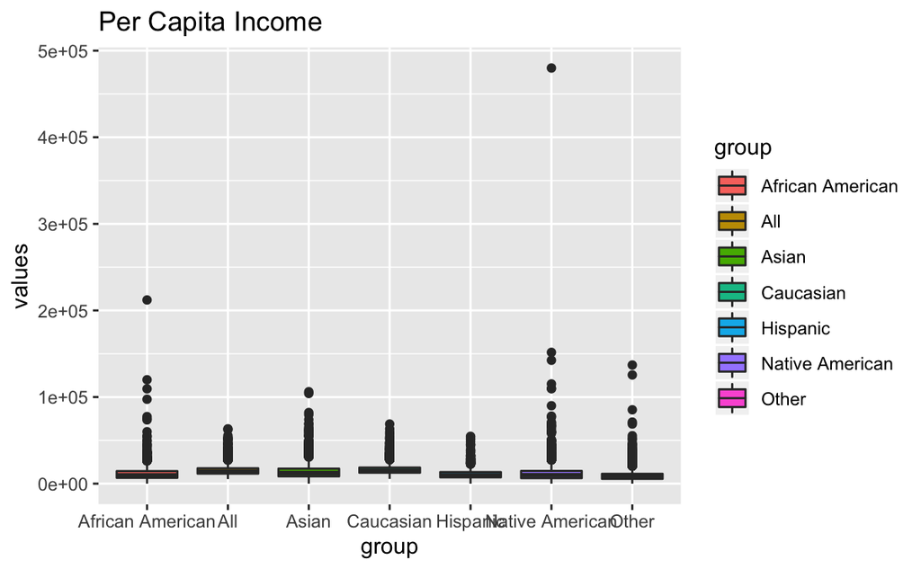

```r
ggplot(data = per_cap_df, aes(x = group, y = values, fill = group)) + geom_boxplot() + ggtitle('Per Capita Income')
```

```r
outlier <- per_cap_df[per_cap_df[['group']] == 'Native American', ]
outlier[outlier[['values']] == max(tst$values), ]
```

|  | values | group |
| --- | --- | --- |
| 6193 | 480000 | Native American |

In terms of missing data, I think that simply filling the values with a predetermined value or removing the observations with missing values could skew the data or be getting rid of possibly meaningful data respectively. I think that maybe the best way to deal with a missing value in this situation would be to fill it with the the average of the column for which it belongs to so that the other variables for the community may be used without to much skewness hopefully. I chose this rather than completely ridding the dataset of rows for which there is some amount of missing data because there might be something in common with all of these communites with some amount of missing data and I would not want to completely disregard this and be getting rid of a specific subgroup of communities.

```r
ind <- c(rep(TRUE, 6192), FALSE, rep(TRUE, 7765))
per_cap_df_wo <- per_cap_df[ind, ]
```

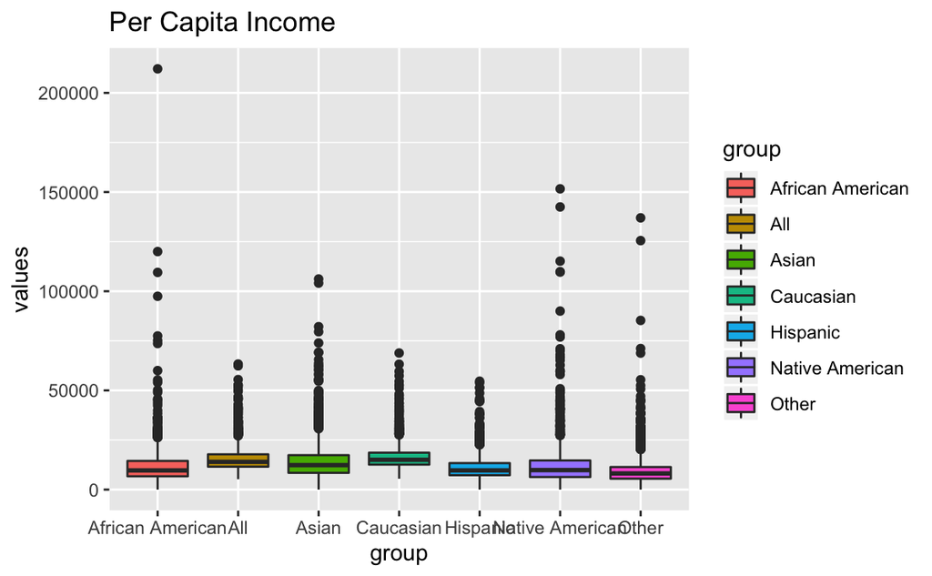

```r
# remove large outlier in Native American Group in order to visualize things better
ggplot(per_cap_df_wo, aes(x = group, y = values, fill = group)) + geom_boxplot() + ggtitle('Per Capita Income')
```

There are quite a few variables to look at specifically 124 and there are probably ones that matter more than others or ones that are correlated enough that having both of them seem redundant. In order to possibly recognize the more important variables for dimension reduction for overall more stable solutions for any type of prediction we are going to do. I think the use of LASSO for dimension reduction would be good. This would allow us to only use the variables that demonstrate the most variation in the data with less variance given so many features. Principal Component Analysis that also provides a form of dimension reduction, but we used that in the other part of the project and in this situation intuitively I think that certain features may be more important in predicting ViolentCrimesPerPop and if we do not use PCA, it allows for our results to be more interpretable as the variables stay as themselves rather than linear combinations of all.

```r
X_wo <- cbind()
for (c in names(X)) {
  col <- X[[c]]
  m <- mean(col, na.rm = TRUE)
  repl <- ifelse(is.na(col), m, col)
  X_wo <- cbind(X_wo, repl)
}
```

```r
X_wo <- data.frame(X_wo)
names(X_wo) <- names(X)
X_wo_mat <- as.matrix(X_wo)
```

```r
library(glmnet)
lambda_seq <- 10^seq(2, -2, by = -.1)
cv_lasso <- cv.glmnet(X_wo_mat, y, alpha = 1, lambda = lambda_seq)
best_lam <- cv_lasso$lambda.min
```

LASSO as a dimension reduction technique identified 39 predictors that would best help predict ViolentCrimesPerPop.

```r
best_lasso <- glmnet(X_wo_mat, y, alpha = 1, lambda = best_lam)
```

# Regression task

In this section, you should use the techniques learned in class to develop a model to predict ViolentCrimesPerPop using the 124 features (or some subset of them) stored in $\mathbf{X}$. Remember that you should try several different methods, and use model selection methods to determine which model is best. You should also be sure to keep a held-out test set to evaluate the performance of your model.

## Linear Regression

```r
coef_df <- data.frame(as.matrix(coef(best_lasso)))
coef_df[['coef']] <- rownames(coef_df)
rownames(coef_df) <- NULL
coef_df <- coef_df[coef_df[['s0']] != 0, ]
coef_df
```

|  | s0 | coef |
| --- | --- | --- |
| 1 | 2.858146e+03 | (Intercept) |
| 4 | 5.068345e+00 | racepctblack |
| 5 | -1.565087e+00 | racePctWhite |
| 9 | -5.128376e+00 | agePct12t29 |
| 13 | 8.941926e-01 | pctUrban |
| 15 | -3.388487e+00 | pctWWage |
| 17 | -3.364414e+00 | pctWInvInc |
| 20 | -5.348202e+00 | pctWRetire |
| 24 | -7.231139e-04 | blackPerCap |
| 26 | 1.427632e-03 | AsianPerCap |

[output cut: 30 more lines]

```r
keep <- coef_df[['coef']][2:40]
keep
```

```
 [1] "racepctblack"          "racePctWhite"          "agePct12t29"           "pctUrban"
 [5] "pctWWage"              "pctWInvInc"            "pctWRetire"            "blackPerCap"
 [9] "AsianPerCap"           "OtherPerCap"           "PctLess9thGrade"       "PctBSorMore"
[13] "PctEmplManu"           "MalePctDivorce"        "PctKids2Par"           "PctWorkMom"
[17] "PctKidsBornNeverMar"   "PctPersDenseHous"      "PctHousLess3BR"        "HousVacant"
[21] "PctHousOccup"          "PctVacantBoarded"      "PctVacMore6Mos"        "RentQrange"
[25] "MedRentPctHousInc"     "MedOwnCostPctIncNoMtg" "NumInShelters"         "PctForeignBorn"
[29] "PctSameCity85"         "LemasSwFTFieldOps"     "LemasSwFTFieldPerPop"  "PolicReqPerOffic"
[33] "RacialMatchCommPol"    "PctPolicAsian"         "OfficAssgnDrugUnits"   "PolicAveOTWorked"
[37] "PolicCars"             "LemasGangUnitDeploy"   "LemasPctOfficDrugUn"
```

```r
nrow(X_wo)
```

```
[1] 1994
```

```r
lasso_data <- X_wo[, keep]
lasso_data[['ViolentCrimesPerPop']] <- y
shuf_lasso_data <- lasso_data[sample(1:nrow(lasso_data), size = nrow(lasso_data)), ]
train_lasso_data <- shuf_lasso_data[1:1500, ]
test_lasso_data <- shuf_lasso_data[1501:nrow(lasso_data), ]
linreg <- lm(ViolentCrimesPerPop ~ ., data = train_lasso_data)
```

Decision trees are really helpful because they provide a really nice visualization and they are easy to interpret. Some things that make it difficult on trainig a tree is deciding at what height we should prune the tree because we don’t want to overfit the data and have the height to be so hight that the tree is no longer able to generalize for data that is not included in the training set.

```r
predict(linreg, test_lasso_data)
```

[output not shown]

[output cut: 45 more lines]

[output not shown]

```r
linreg_cv <- c()
for (i in 0:4) {
  ind <- ((300 * i) + 1):(300 * (i + 1))
  train <- train_lasso_data[-ind, ]
  test <- train_lasso_data[ind, ]
  true_val <- test[['ViolentCrimesPerPop']]
  fit <- lm(ViolentCrimesPerPop ~ ., data = train)
  pred <- predict(fit, test)
  linreg_cv <- c(linreg_cv, mean((pred - true_val) ^ 2))
}
linreg_cv
```

```
[1] 111674.7 134258.1 145179.2 122658.5 127884.4
```

```r
mean(linreg_cv)
```

```
[1] 128331
```

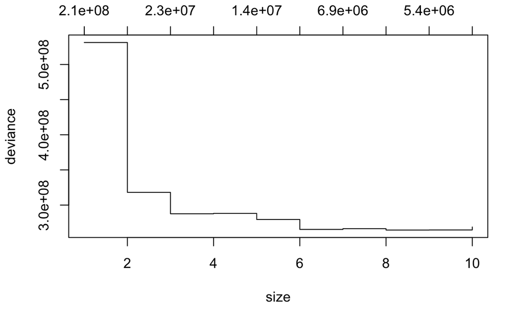

```r
library(tree)
tree_vcpp <- tree(ViolentCrimesPerPop ~., data = train_lasso_data)
cv_tree_vcpp <- cv.tree(tree_vcpp, FUN = prune.tree)
plot(cv_tree_vcpp)
```

We could have improved some sort of accuracy for the prediction of the decision trees by bootstrapping the training data, fitting a tree, and then averaging the predictions as our final prediction. This process is called bagging, but all of these trees are correlated to each other. Random forests impove this by decorrelating the trees since at each node split a random sample of a given number of predictors is chosen for the elements to be split on.

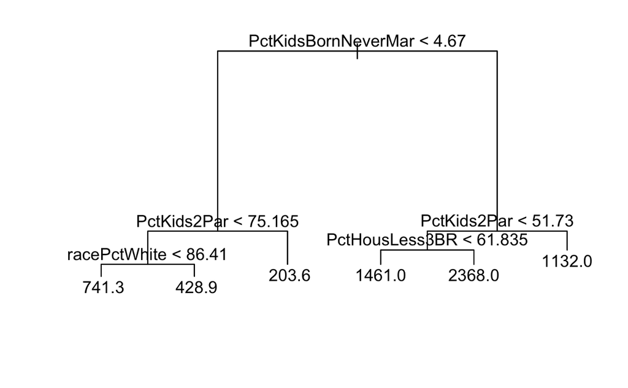

```r
pruned_tree_vcpp <- prune.tree(tree_vcpp, best = 6)
plot(pruned_tree_vcpp)
text(pruned_tree_vcpp, pretty = 0)
```

```r
dec_tree_cv <- c()
for (i in 0:4) {
  ind <- ((300 * i) + 1):(300 * (i + 1))
  train <- train_lasso_data[-ind, ]
  test <- train_lasso_data[ind, ]
  true_val <- test[['ViolentCrimesPerPop']]
  pruned_tree <- prune.tree(tree(ViolentCrimesPerPop ~., data = train), best = 6)
  pred <- predict(pruned_tree, test)
  dec_tree_cv <- c(dec_tree_cv, mean((pred - true_val) ^ 2))
}
dec_tree_cv
```

```
[1] 182256.3 177918.0 235617.4 207944.9 177487.7
```

```r
mean(dec_tree_cv)
```

```
[1] 196244.9
```

```r
tst <- randomForest(ViolentCrimesPerPop ~ ., data = train_lasso_data, mtry = 10)
preds <- predict(tst, test_lasso_data)
mean((preds - test_lasso_data[['ViolentCrimesPerPop']]) ^ 2)
```

```
[1] 158158.7
```